# Exploratory Data Analysis of white wine data by Dheeraj R Kondati

# I.DATASET INFORMATION

## 1.CITATION:

This dataset is public available for research. The details are described in [Cortez et al., 2009].

P. Cortez, A. Cerdeira, F. Almeida, T. Matos and J. Reis. Modeling wine preferences by data mining from physicochemical properties. In Decision Support Systems, Elsevier, 47(4):547-553. ISSN: 0167-9236.

Available at: [@Elsevier] http://dx.doi.org/10.1016/j.dss.2009.05.016 [Pre-press (pdf)] http://www3.dsi.uminho.pt/pcortez/winequality09.pdf [bib] http://www3.dsi.uminho.pt/pcortez/dss09.bib

## 2.TITLE:

Wine Quality-White Wine

## 3.ABOUT:

This data set contains 4,898 white wines with 11 variables on quantifying the chemical properties of each wine. At least 3 wine experts rated the quality of each wine, providing a rating between 0 (very bad) and 10 (very excellent).

## 4.Number of Instances: 4898

## 5.Attributes:

There are 11 input attributes and one output attribute and one serial number attribute.

### Input Attributes

Based on physicochemical tests 1-fixed acidity (tartaric acid - g / dm^3) 2-volatile acidity (acetic acid - g / dm^3) 3-citric acid (g / dm^3) 4-residual sugar (g / dm^3) 5-chlorides (sodium chloride - g / dm^3 6-free sulfur dioxide (mg / dm^3) 7-total sulfur dioxide (mg / dm^3) 8-density (g / cm^3) 9-pH 10-sulphates (potassium sulphate - g / dm3) 11-alcohol (% by volume)

### Output variable (based on sensory data)

12 - quality (score between 0 and 10)

### Serial Number Attribute

X-1-4898

## 6.Attribute Information

1 - fixed acidity: most acids involved with wine or fixed or nonvolatile (do not evaporate readily)  
2 - volatile acidity: the amount of acetic acid in wine, which at too high of levels can lead to an unpleasant, vinegar taste  
3 - citric acid: found in small quantities, citric acid can add ‘freshness’ and flavor to wines  
4 - residual sugar: the amount of sugar remaining after fermentation stops, it’s rare to find wines with less than 1 gram/liter and wines with greater than 45 grams/liter are considered sweet  
5 - chlorides: the amount of salt in the wine  
6 - free sulfur dioxide: the free form of SO2 exists in equilibrium between molecular SO2 (as a dissolved gas) and bisulfite ion; it prevents microbial growth and the oxidation of wine  
7 - total sulfur dioxide: amount of free and bound forms of S02; in low concentrations, SO2 is mostly undetectable in wine, but at free SO2 concentrations over 50 ppm, SO2 becomes evident in the nose and taste of wine  
8 - density: the density of water is close to that of water depending on the percent alcohol and sugar content  
9 - pH: describes how acidic or basic a wine is on a scale from 0 (very acidic) to 14 (very basic); most wines are between 3-4 on the pH scale  
10 - sulphates: a wine additive which can contribute to sulfur dioxide gas (S02) levels, wich acts as an antimicrobial and antioxidant  
11 - alcohol: the percent alcohol content of the wine

Output variable (based on sensory data):  
12 - quality (score between 0 and 10)

# II.OVERVIEW OF THE DATA

Dimensions of Data

```
## [1] 4898   13
```

The first 5 rows of the dataset

```
##   X fixed.acidity volatile.acidity citric.acid residual.sugar chlorides
## 1 1           7.0             0.27        0.36           20.7     0.045
## 2 2           6.3             0.30        0.34            1.6     0.049
## 3 3           8.1             0.28        0.40            6.9     0.050
## 4 4           7.2             0.23        0.32            8.5     0.058
## 5 5           7.2             0.23        0.32            8.5     0.058
## 6 6           8.1             0.28        0.40            6.9     0.050
##   free.sulfur.dioxide total.sulfur.dioxide density   pH sulphates alcohol
## 1                  45                  170  1.0010 3.00      0.45     8.8
## 2                  14                  132  0.9940 3.30      0.49     9.5
## 3                  30                   97  0.9951 3.26      0.44    10.1
## 4                  47                  186  0.9956 3.19      0.40     9.9
## 5                  47                  186  0.9956 3.19      0.40     9.9
## 6                  30                   97  0.9951 3.26      0.44    10.1
##   quality
## 1       6
## 2       6
## 3       6
## 4       6
## 5       6
## 6       6
```

Summary of datatypes of the attributes

```
## 'data.frame':    4898 obs. of  13 variables:
##  $ X                   : int  1 2 3 4 5 6 7 8 9 10 ...
##  $ fixed.acidity       : num  7 6.3 8.1 7.2 7.2 8.1 6.2 7 6.3 8.1 ...
##  $ volatile.acidity    : num  0.27 0.3 0.28 0.23 0.23 0.28 0.32 0.27 0.3 0.22 ...
##  $ citric.acid         : num  0.36 0.34 0.4 0.32 0.32 0.4 0.16 0.36 0.34 0.43 ...
##  $ residual.sugar      : num  20.7 1.6 6.9 8.5 8.5 6.9 7 20.7 1.6 1.5 ...
##  $ chlorides           : num  0.045 0.049 0.05 0.058 0.058 0.05 0.045 0.045 0.049 0.044 ...
##  $ free.sulfur.dioxide : num  45 14 30 47 47 30 30 45 14 28 ...
##  $ total.sulfur.dioxide: num  170 132 97 186 186 97 136 170 132 129 ...
##  $ density             : num  1.001 0.994 0.995 0.996 0.996 ...
##  $ pH                  : num  3 3.3 3.26 3.19 3.19 3.26 3.18 3 3.3 3.22 ...
##  $ sulphates           : num  0.45 0.49 0.44 0.4 0.4 0.44 0.47 0.45 0.49 0.45 ...
##  $ alcohol             : num  8.8 9.5 10.1 9.9 9.9 10.1 9.6 8.8 9.5 11 ...
##  $ quality             : int  6 6 6 6 6 6 6 6 6 6 ...
```

From the summary above,we can observe that quality and X is an integer class,while others are stored as the numeric class

Overall Summary of all attributes

```
##        X        fixed.acidity    volatile.acidity  citric.acid
##  Min.   :   1   Min.   : 3.800   Min.   :0.0800   Min.   :0.0000
##  1st Qu.:1225   1st Qu.: 6.300   1st Qu.:0.2100   1st Qu.:0.2700
##  Median :2450   Median : 6.800   Median :0.2600   Median :0.3200
##  Mean   :2450   Mean   : 6.855   Mean   :0.2782   Mean   :0.3342
##  3rd Qu.:3674   3rd Qu.: 7.300   3rd Qu.:0.3200   3rd Qu.:0.3900
##  Max.   :4898   Max.   :14.200   Max.   :1.1000   Max.   :1.6600
##  residual.sugar     chlorides       free.sulfur.dioxide
##  Min.   : 0.600   Min.   :0.00900   Min.   :  2.00
##  1st Qu.: 1.700   1st Qu.:0.03600   1st Qu.: 23.00
##  Median : 5.200   Median :0.04300   Median : 34.00
##  Mean   : 6.391   Mean   :0.04577   Mean   : 35.31
##  3rd Qu.: 9.900   3rd Qu.:0.05000   3rd Qu.: 46.00
##  Max.   :65.800   Max.   :0.34600   Max.   :289.00
##  total.sulfur.dioxide    density             pH          sulphates
##  Min.   :  9.0        Min.   :0.9871   Min.   :2.720   Min.   :0.2200
##  1st Qu.:108.0        1st Qu.:0.9917   1st Qu.:3.090   1st Qu.:0.4100
##  Median :134.0        Median :0.9937   Median :3.180   Median :0.4700
##  Mean   :138.4        Mean   :0.9940   Mean   :3.188   Mean   :0.4898
##  3rd Qu.:167.0        3rd Qu.:0.9961   3rd Qu.:3.280   3rd Qu.:0.5500
##  Max.   :440.0        Max.   :1.0390   Max.   :3.820   Max.   :1.0800
##     alcohol         quality
##  Min.   : 8.00   Min.   :3.000
##  1st Qu.: 9.50   1st Qu.:5.000
##  Median :10.40   Median :6.000
##  Mean   :10.51   Mean   :5.878
##  3rd Qu.:11.40   3rd Qu.:6.000
##  Max.   :14.20   Max.   :9.000
```

From the summary, we can observe that there are a few attributes with outliers,namely residual.sugar and free.sulphur.dioxide.

# III Single Variable Analysis

## Overview of each variable

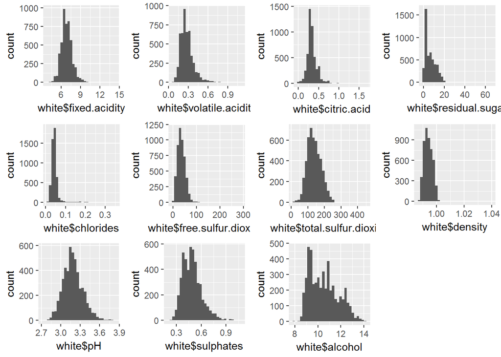

Outliers and long tails can be seen from the intital overview,a few of the outliers are cleaned

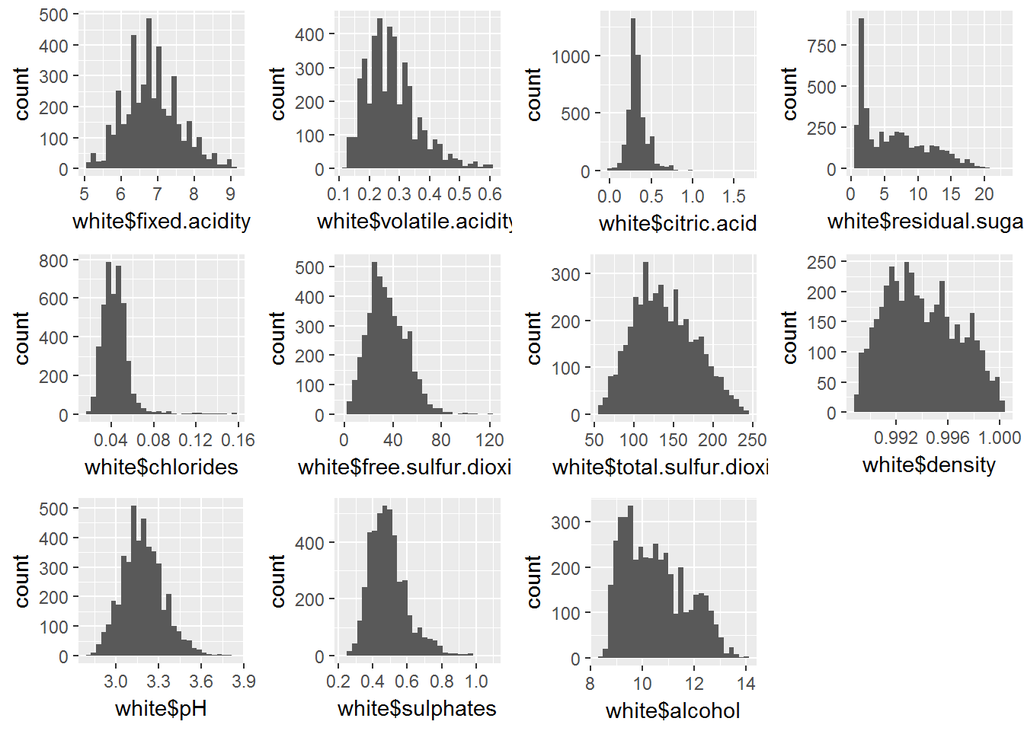

## Closer look at the data

### a)Acidity

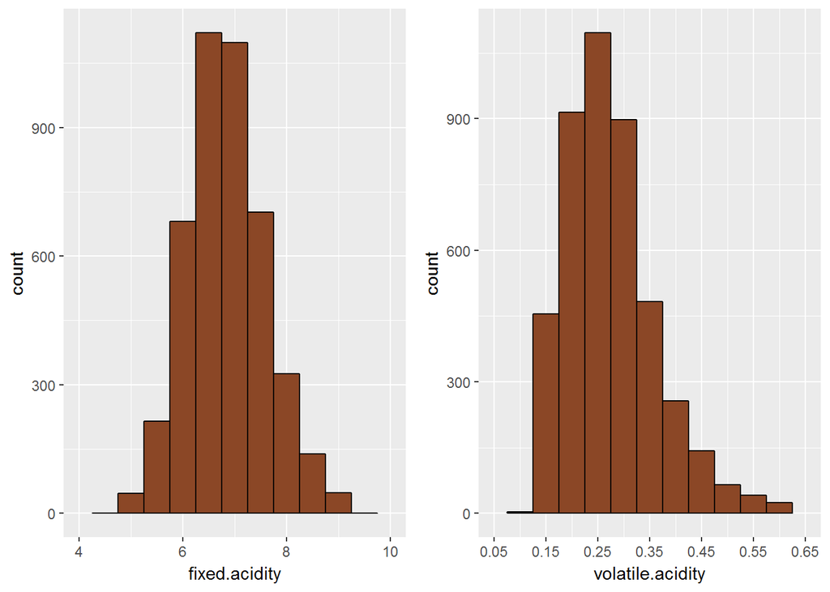

From the plots, we can observe a slight skewness in both the acidity values, most of the values for fixed acidity is between 6-8 and for volatile acidity is between 0.2 to 0.3. There are outliers which are eliminated from the plots.

### b)Sulphurdioxide(SO2) content

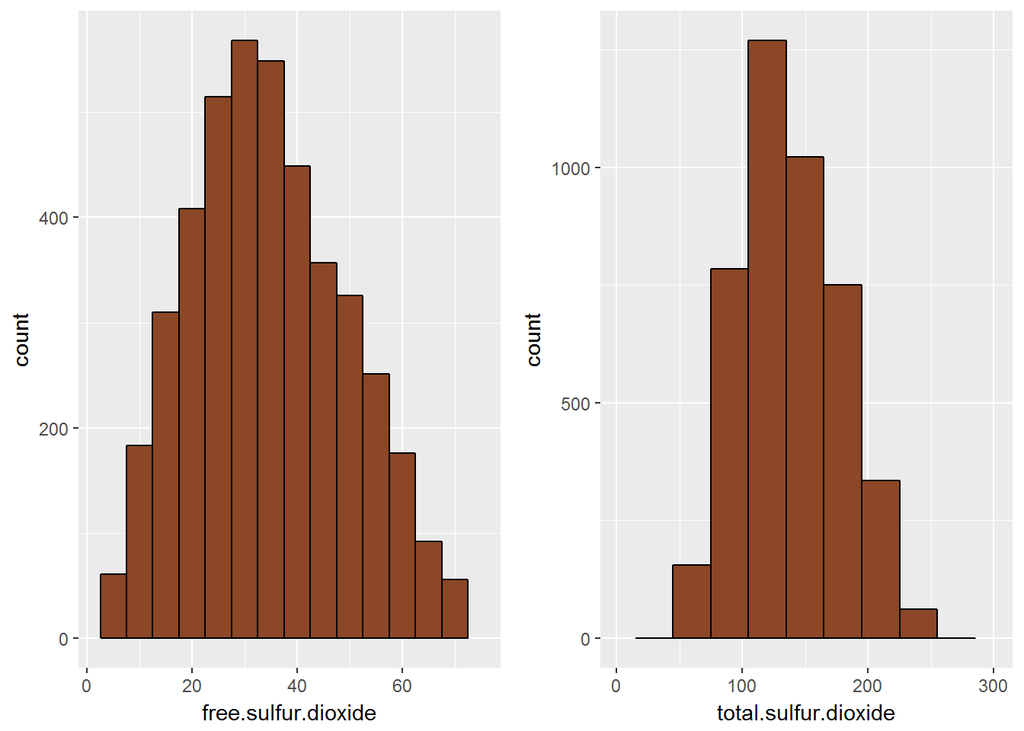

Both the free sulphur dioxide and total sulphur dioxide have long tails,these data points have been eiminated from the graph.Most of the data points for total SO2 are between 100-160 and for free SO2, they are between 20-40.

### Chemical Compositions

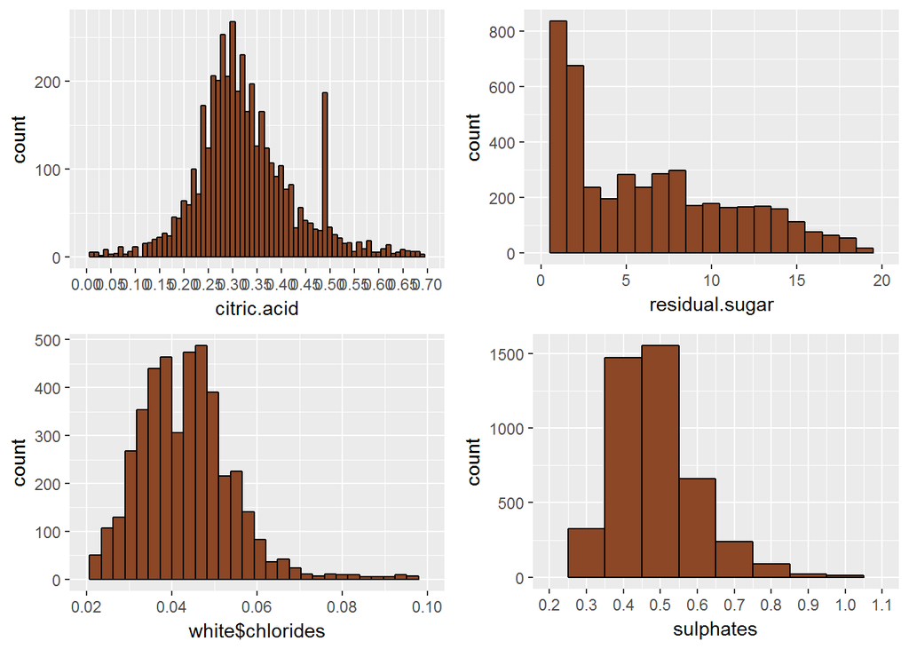

Residual.Sugar is heavily skewed with nearly half of the data within 0-5, White chlorides have most of the data between 0.025-0.07,Sulphates have a long tail and citric.acid shows an unusual peak near 0.5.

### pH

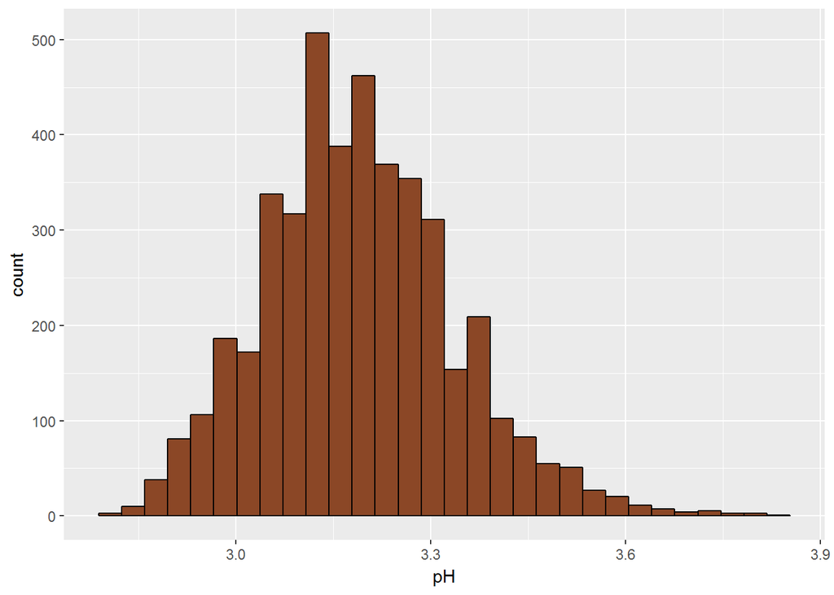

Fairly Normal Distribution of pH values,most of the values between 3.1 and 3.3

### Density

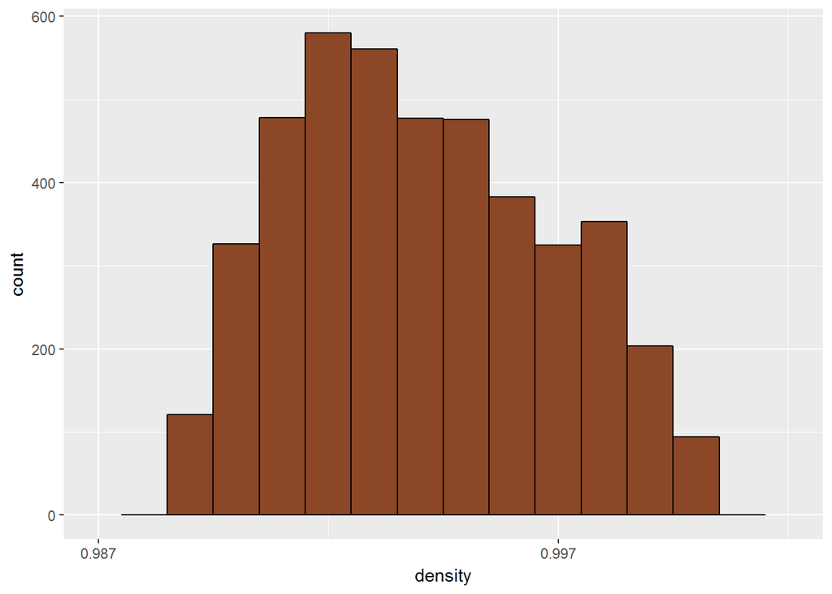

Density data has outlier data points and a long tail,the plot does not show the tail.

### Quality

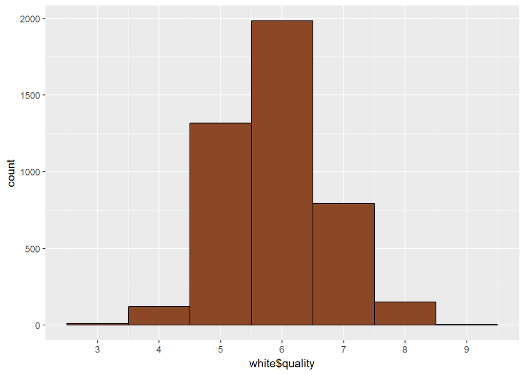

Most of the wines are rated at 5 and 6

### What is the structure of your dataset?

There are 4898 instances of white wines with 11 independent attributes for each wine,each wine is rated on a scale of 1-10 which is the dependent variable as it is influenced by the attributes.

### What is/are the main feature(s) of interest in your dataset?

Main feature of interest of the dataset is to observe how each attribute influences the quality of the alcohol.But from knowledge we can say that alcohol could be a driving feature as it is the most important chemical component of wine.A model could be built based on the relation between the attributes and quality which could predict the quality given attributes of a new wine.

### What other features in the dataset do you think will help support your investigation into your feature(s) of interest?

Based on the initial view of the data, any of the variables could influence the quality so no variable can be ruled out yet.Certainly Alcohol will be an important feature.On observation of correlations between attributes and quality a deduction could be made in the attribute space.

### Did you create any new variables from existing variables in the dataset?

No new variables have been created.But new variables could be created which would segment the variables to create better visualisations.

### Of the features you investigated, were there any unusual distributions? Did you perform any operations on the data to tidy, adjust, or change the form of the data? If so, why did you do this?

There are a few outliers in the dataset which have been eliminated.Mainly the datapoints above the 99 percentile and below the 0.01 percentile have been removed from the following attributes fixed.acidity, volatile.acidity,chlorides,total.sulfur.dioxide,density.

# Bivariate Plots Section

### Correlations Plot

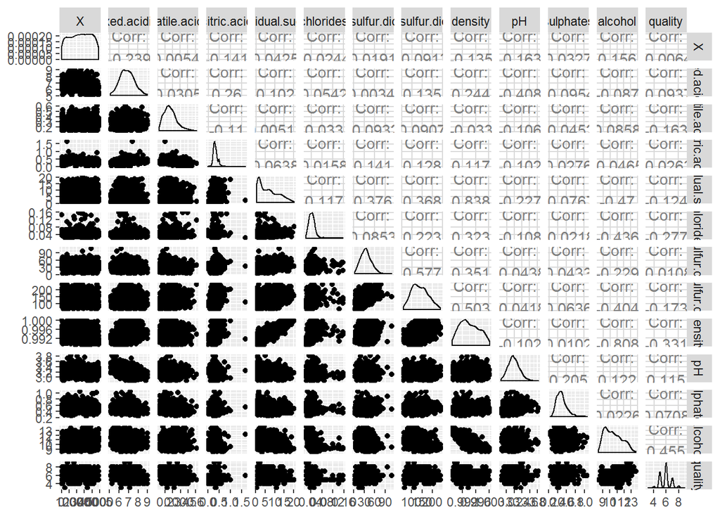

We are more interested in checking the influence of attributes on quality,lets look at those plots first.

### Alcohol Influence on quality

Wine has relaxing effects,from our knowledge we know that Alcohol is the reason.Lets check how alcohol levels influence quality of the wine.

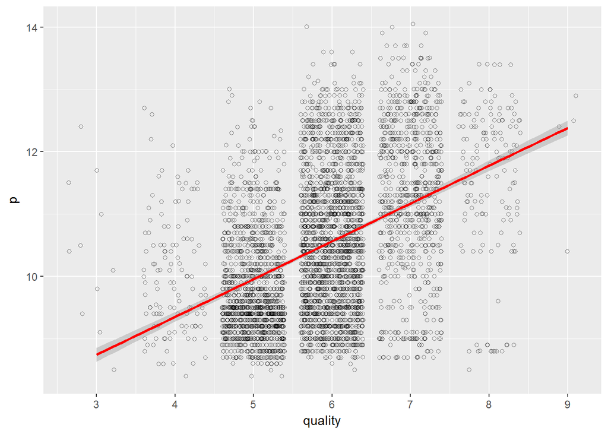

It can be seen that as the alcohol level increases,the wine rating increases

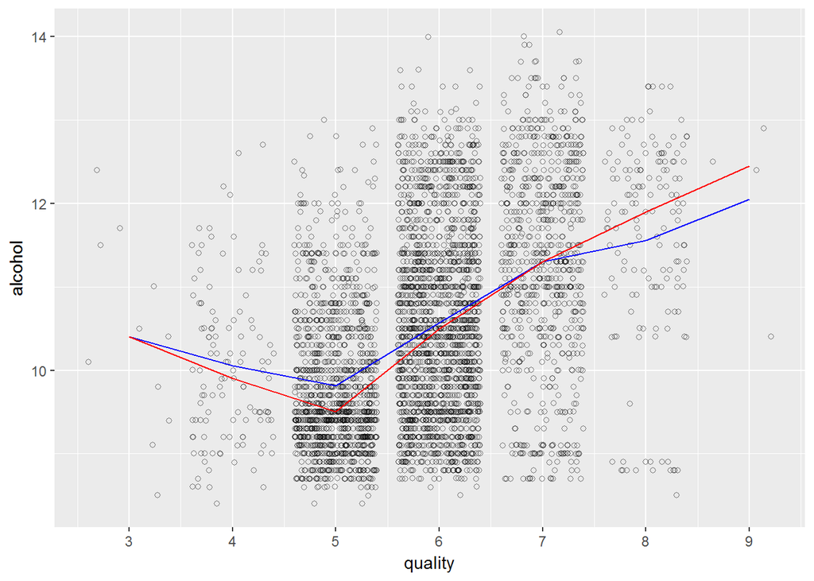

The lines in the plot are the median and mean alcohol levels across each level of quality.It can be seen that there is an increasing trend.

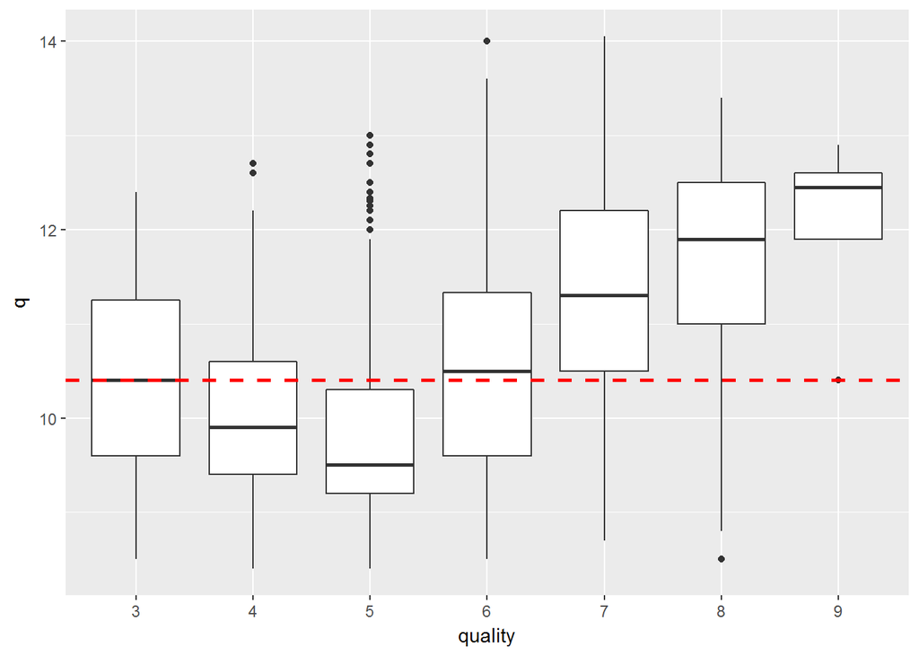

The red line is the overall median of alcohol values,higher alcohol content clearly signifies better wine.

### citirc acidinfluence on quality

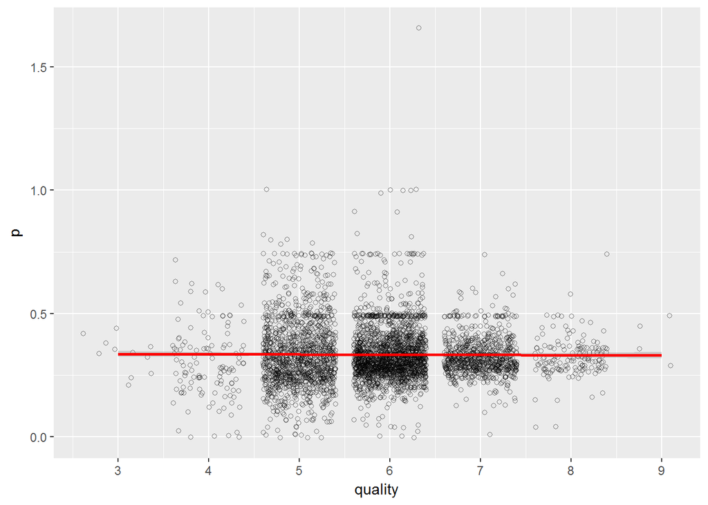

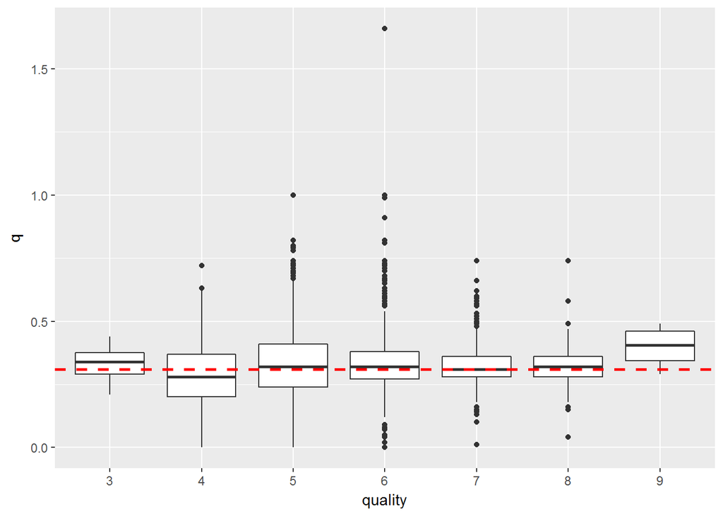

### sulphates influence on quality

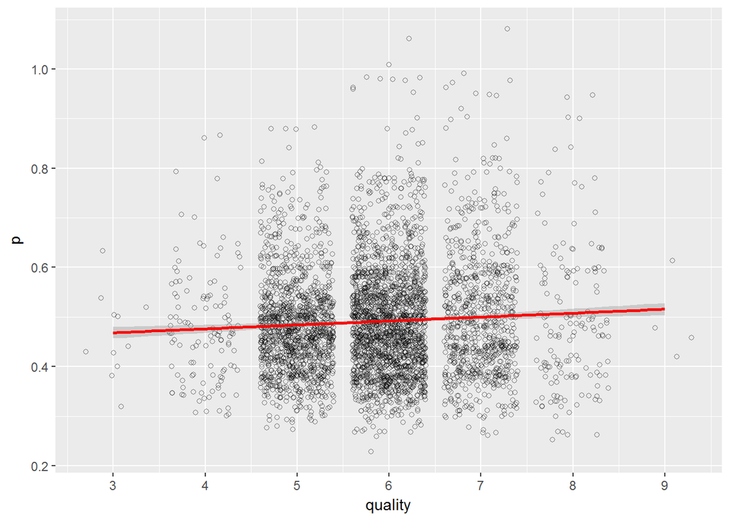

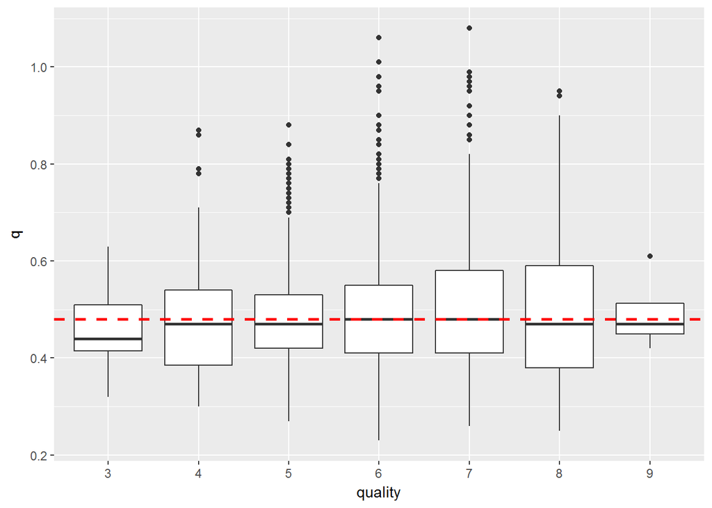

### acidity on quality

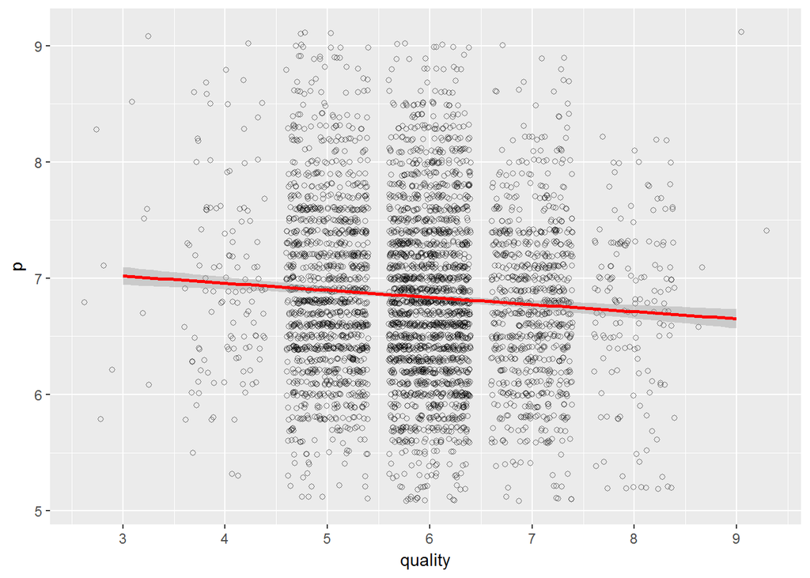

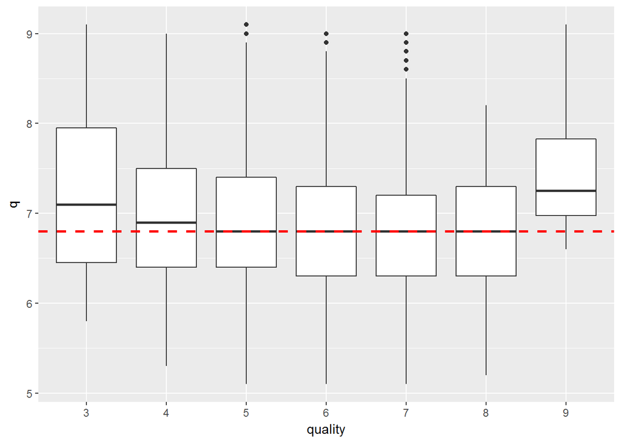

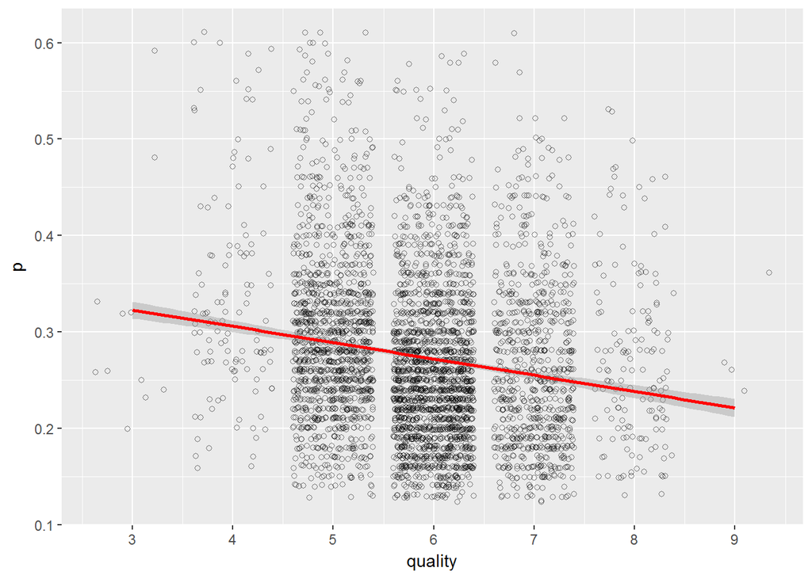

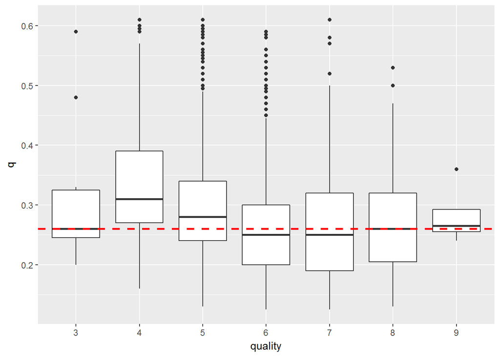

### chlorides

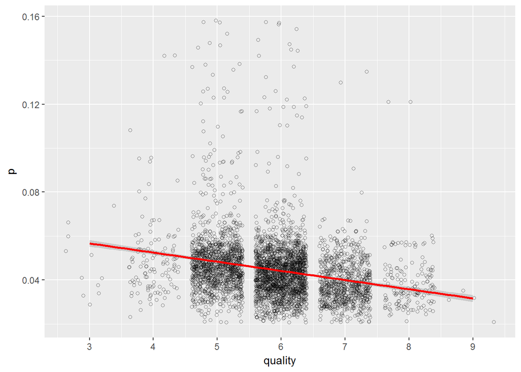

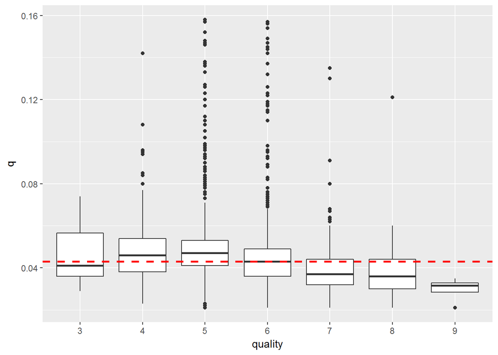

### residual.sugar

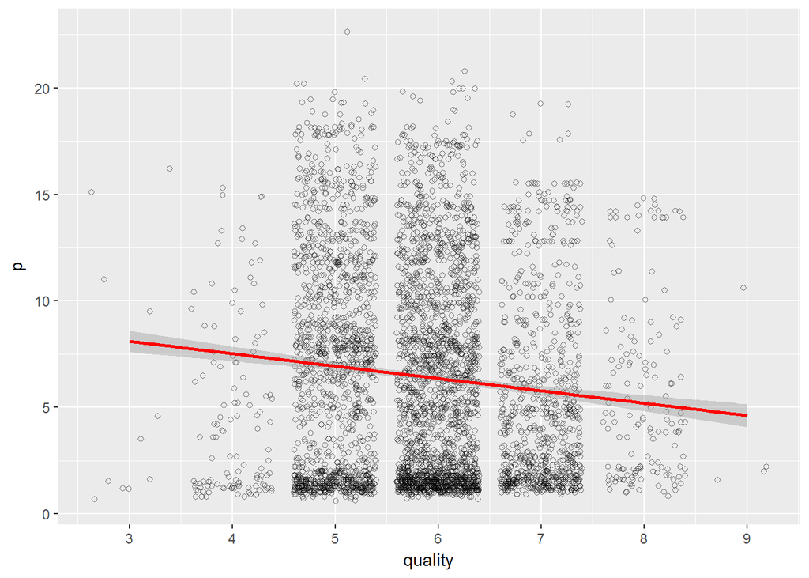

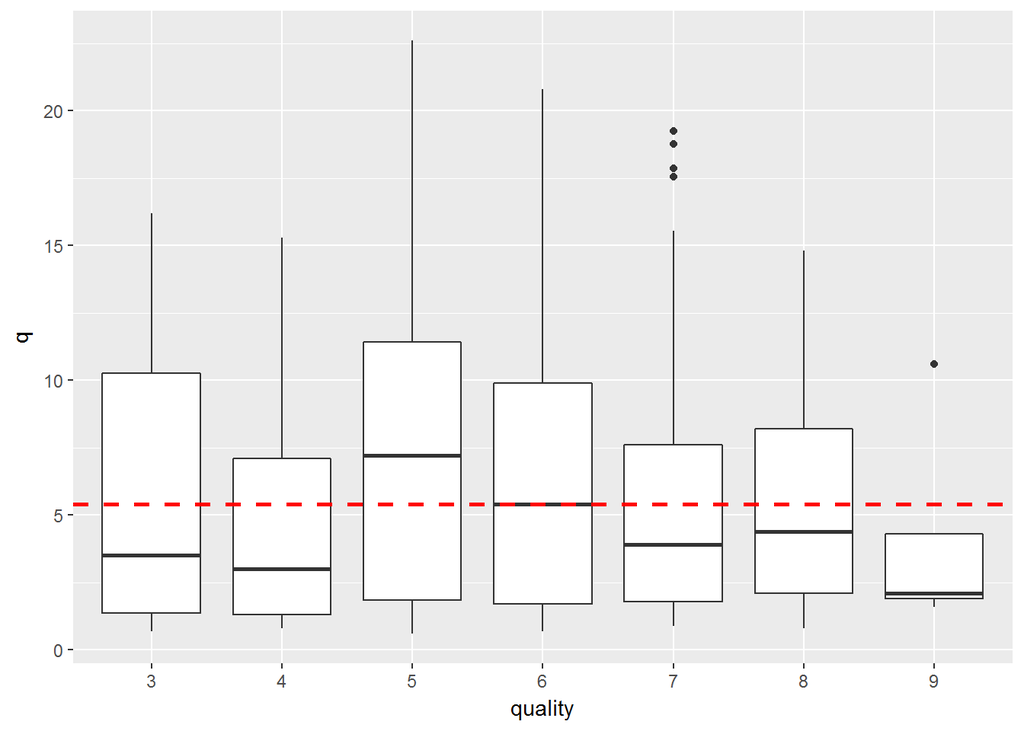

### pH

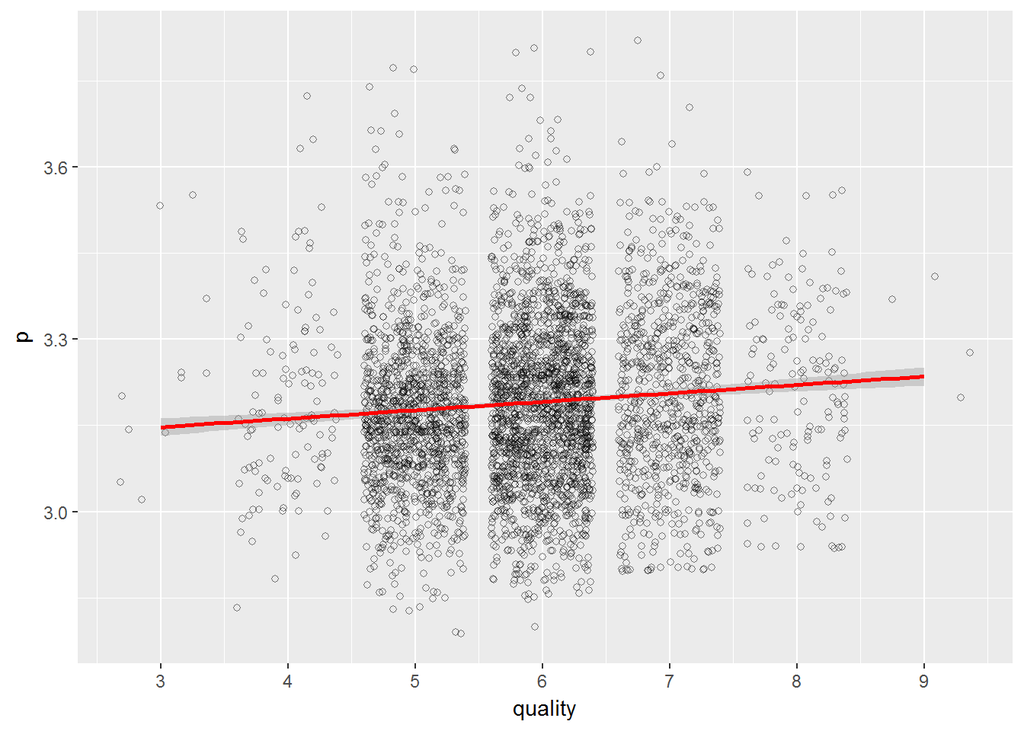

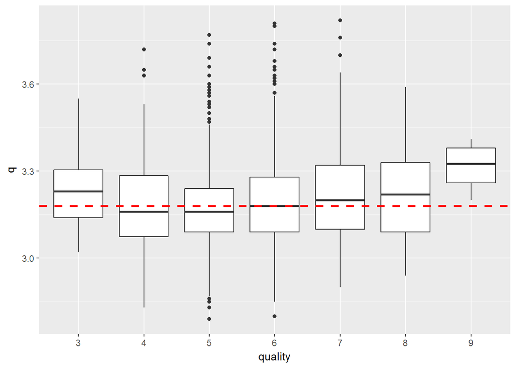

### Summary of attributes on Quality

1.Citric acid,sulphates and fixed acidity have negligible influence on Quality.  
2.As volatile acidity,chlorides and resudial sugar decrease the quality increases.  
3.As pH value increases, Quality increases.

## Looking at other strong correlations

### Alcohol vs Density

From the scatterplot of correlations ALcohol and Density have high correlation of -0.8.

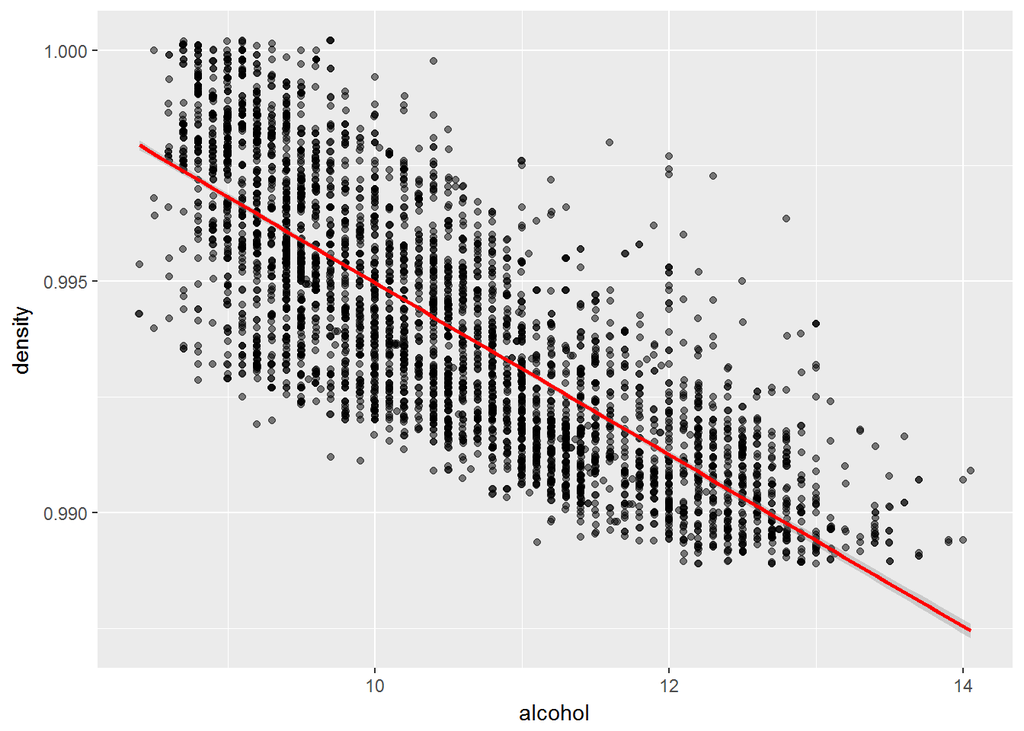

The plot shows that there is a decreasing trend, as alcohol increases density decreases.

### density vs residual sugar

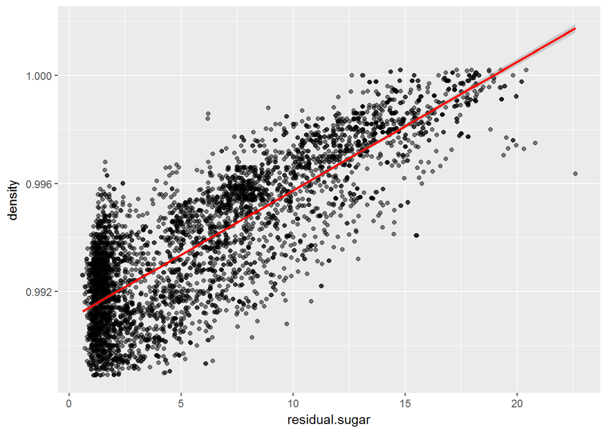

Clearly as sugar level increases the wine becomes denser.

### density vs Total Sulfur dioxide

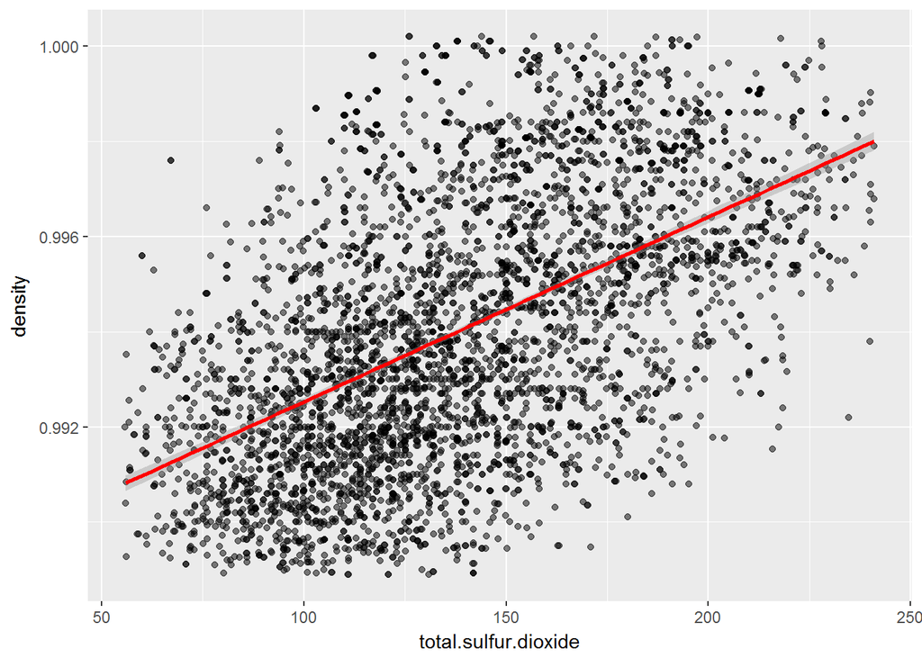

Denser wines have more total sulfur dioxide.

### Talk about some of the relationships you observed in this part of the investigation. How did the feature(s) of interest vary with other features in the dataset?

Alcohol,density,residual sugar and total sufur dioxide have been found to be either strongly correlated to one another or have influenced quality.  
Summary  
1.Citric acid,sulphates and fixed acidity have negligible influence on Quality.  
2.As volatile acidity,chlorides and resudial sugar decrease the quality increases.  
3.As pH value increases, Quality increases.

### Did you observe any interesting relationships between the other features (not the main feature(s) of interest)?

There are a few strongly correlated attributes.  
Summary  
1.As alcohol increases density decreases.The smoothing line slopes downwards from left to right which supports this conslusion.Also the median values of higher quality wines are much more than the overall median.  
2.As sugar level increases the wine becomes denser.  
3.Denser wines have more total sulfur dioxide.

### What was the strongest relationship you found?

density and sugar are very highly correlated,Alcohol and density are also correlated but negatively. The plots and correlation values support this conclusion as shown above.

# Multivariate Plots Section

### Alcohol vs density quality

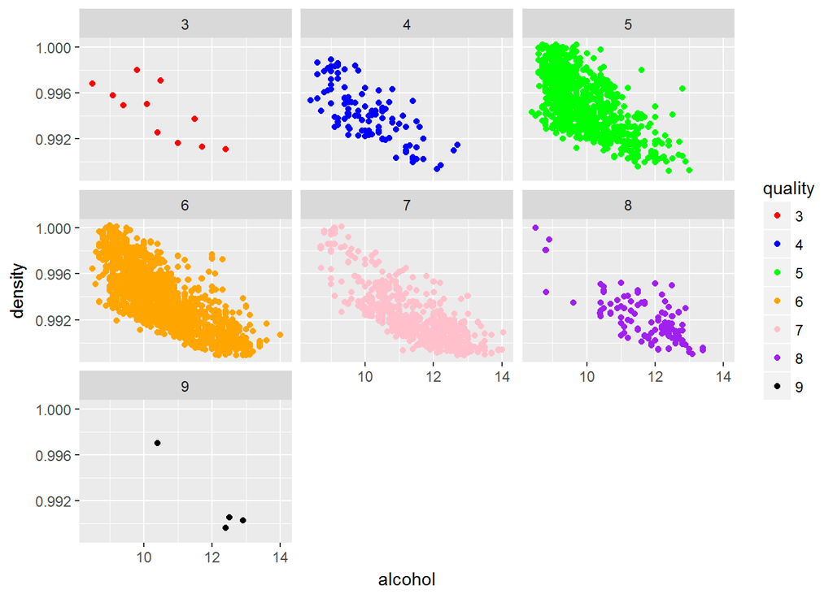

From the plot,it is clarly seen that as alcohol increases and density decreases ,the wine gets a better rating

### Density vs residual sugar and alcohol

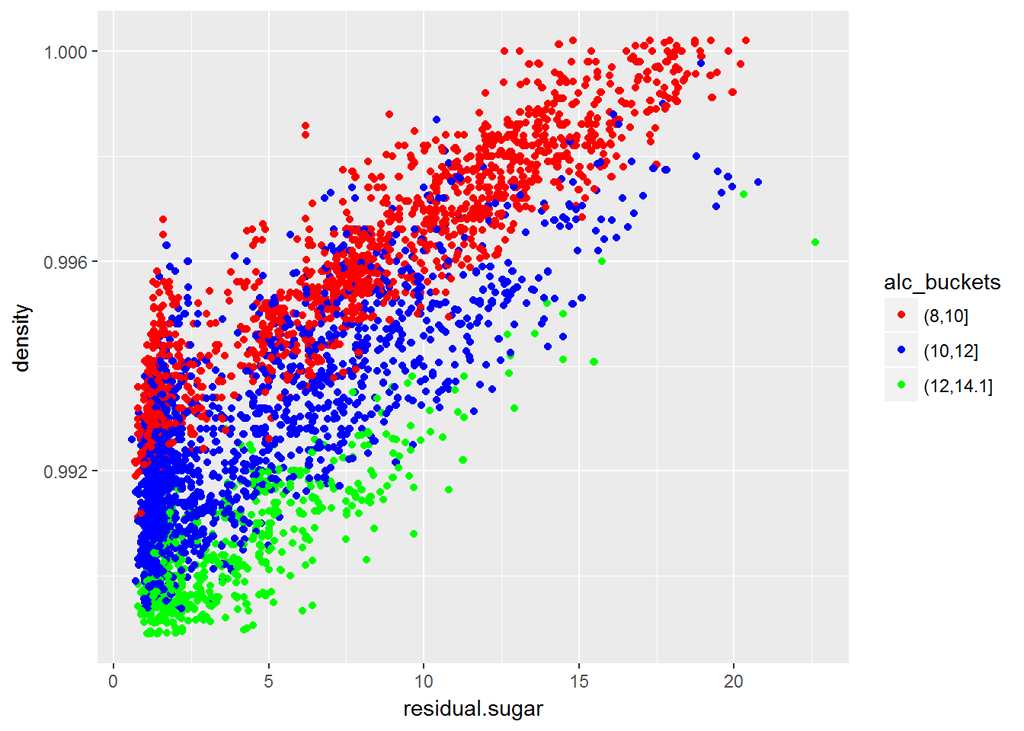

Highly dense wines have less alcohol and more sweetness.  
Wines with higher alcohol contents have less density and sweetness.

### Density vs Total sulfur dioxide vs alcohol

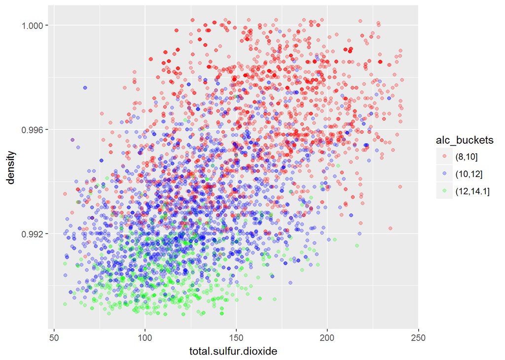